# A Composition Benchmark for UI Claims Intensity

### Annual Frequency

To facilitate comparison with the state-panel gap exercise in Section 7.5, I also estimate the national composition model at annual frequency. Aggregating to annual removes seasonal variation and aligns the national exercise with the annual state panel. Without month-of-year fixed effects, the annual specification is:

$$\bar{y}_t = \alpha + \sum_{c \neq \text{CTJ}} \beta_c \, \bar{s}_{ct} + \varepsilon_t$$

where $\bar{y}_t$ and $\bar{s}_{ct}$ are annual averages of claims intensity and cause shares, respectively.

```r
annual_rhs <- "temp_layoff_share + perm_job_loser_share + job_leaver_share + reentrant_share + new_entrant_share"
cc_annual_nat <- lm(as.formula(paste0("cc_ce ~ ", annual_rhs)), data = national_annual)
ic_annual_nat <- lm(as.formula(paste0("ic_ce ~ ", annual_rhs)), data = national_annual)
national_annual <- national_annual |>
  mutate(cc_ce_hat = predict(cc_annual_nat), ic_ce_hat = predict(ic_annual_nat),
         cc_gap = cc_ce - cc_ce_hat, ic_gap = ic_ce - ic_ce_hat)
```

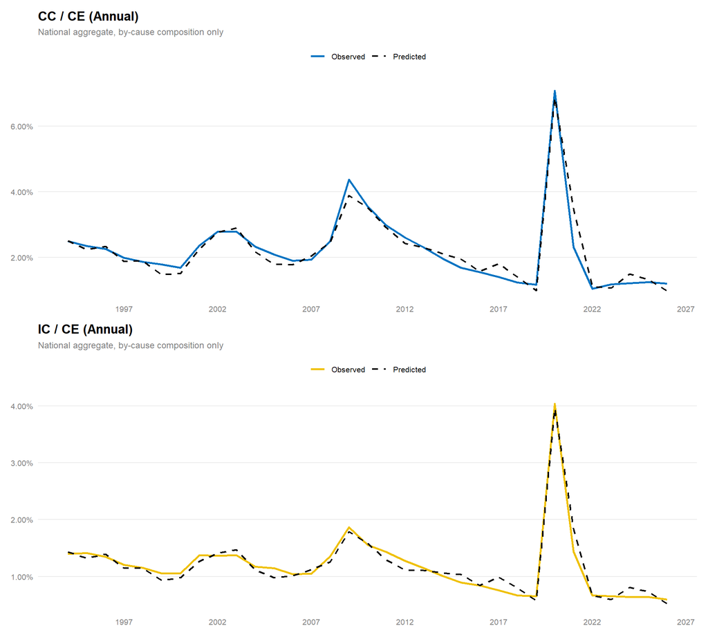

Figure 32: Observed versus composition-predicted national claims intensity at annual frequency. This is the national analog of the state-panel gap exercise.

```r
(ggplot(national_annual, aes(date)) +
   geom_line(aes(y = cc_ce, color = "Observed"), linewidth = 0.9) +
   geom_line(aes(y = cc_ce_hat, color = "Predicted"), linewidth = 0.8, linetype = "dashed") +
   scale_color_manual(values = c("Observed" = "#0073C2", "Predicted" = "black")) +
   scale_x_date(date_breaks = "5 years", date_labels = "%Y") +
   scale_y_continuous(labels = percent_format(accuracy = 0.01)) +
   labs(title = "CC / CE (Annual)", subtitle = "National aggregate, by-cause composition only", x = NULL, y = NULL)) /
  (ggplot(national_annual, aes(date)) +
     geom_line(aes(y = ic_ce, color = "Observed"), linewidth = 0.9) +
     geom_line(aes(y = ic_ce_hat, color = "Predicted"), linewidth = 0.8, linetype = "dashed") +
     scale_color_manual(values = c("Observed" = "#EFC000", "Predicted" = "black")) +
     scale_x_date(date_breaks = "5 years", date_labels = "%Y") +
     scale_y_continuous(labels = percent_format(accuracy = 0.01)) +
     labs(title = "IC / CE (Annual)", subtitle = "National aggregate, by-cause composition only", x = NULL, y = NULL)) &
  theme(legend.position = "top")
```

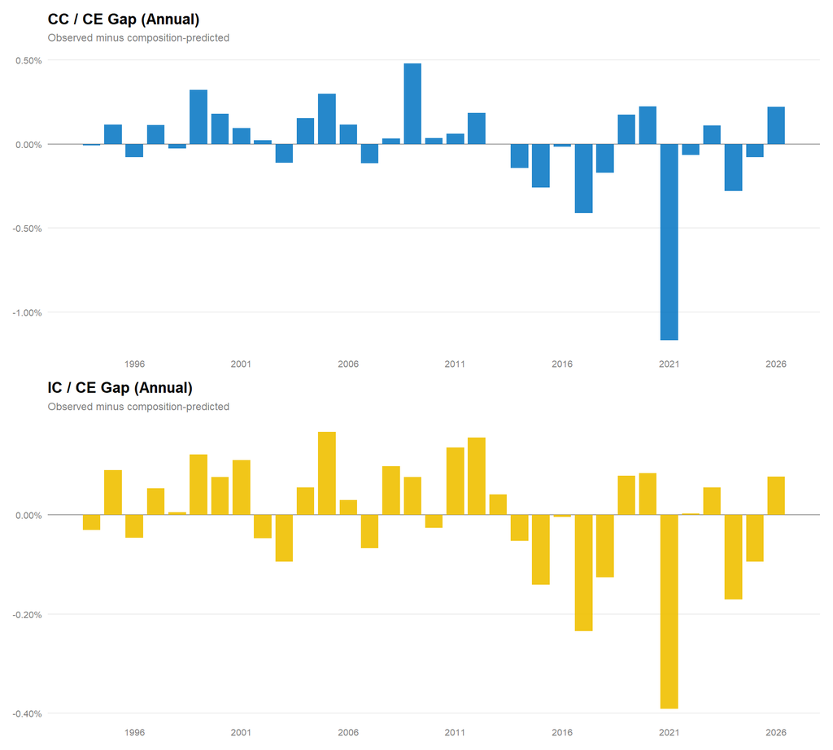

Figure 33: Annual national composition gap. Compare with the state-panel gap in Section 7.5.

```r
(ggplot(national_annual, aes(date, cc_gap)) +
   geom_hline(yintercept = 0, color = "grey60", linewidth = 0.5) +
   geom_col(fill = "#0073C2", alpha = 0.85, width = 300) +
   scale_x_date(date_breaks = "5 years", date_labels = "%Y") +
   scale_y_continuous(labels = percent_format(accuracy = 0.01)) +
   labs(title = "CC / CE Gap (Annual)", subtitle = "Observed minus composition-predicted", x = NULL, y = NULL)) /
  (ggplot(national_annual, aes(date, ic_gap)) +
     geom_hline(yintercept = 0, color = "grey60", linewidth = 0.5) +
     geom_col(fill = "#EFC000", alpha = 0.9, width = 300) +
     scale_x_date(date_breaks = "5 years", date_labels = "%Y") +
     scale_y_continuous(labels = percent_format(accuracy = 0.01)) +
     labs(title = "IC / CE Gap (Annual)", subtitle = "Observed minus composition-predicted", x = NULL, y = NULL))
```

## 7.3 Robustness: Macro Labor-Market Benchmarks

Because the national monthly fit may partly reflect broad aggregate forces that jointly shape unemployment composition and claims intensity, this subsection compares the composition benchmark with alternative monthly macro labor-market benchmarks. These exercises are descriptive and reduced form; they do not identify causal effects. The goal is to evaluate whether unemployment composition has predictive or interpretive value beyond broad labor-market conditions, or whether any variable set correlated with the same omitted aggregate forces can track the national time path of claims intensity equally well.

- **Model A (Composition):** the by-cause unemployment shares from Section 7.1. This is the paper’s main benchmark, included here as the reference point.
- **Model B (Unemployment rate):** the headline U-3 unemployment rate alone. This is the most natural strawman: if the level of unemployment is all that matters for claims intensity, composition adds nothing.
- **Model C (Expanded aggregate):** U-3, labor force participation rate, employment-population ratio, and year-over-year payroll employment growth.
- **Model D (Slack/duration):** U-6 underemployment rate, short-term unemployment share, long-term unemployment share, and median unemployment duration.
- **Model E (JOLTS):** job openings rate, hires rate, quits rate, and layoffs-and-discharges rate. The shorter sample begins in December 2000.
- **Model F (Nested):** the expanded aggregate variables from Model C plus the composition shares.

The specifications are:

**Model A (Composition):**
$$y_t = \alpha + \sum_{c \neq \text{CTJ}} \beta_c \, s_{ct} + \sum_{m=2}^{12} \gamma_m \mathbf{1}\{\text{month}(t) = m\} + \varepsilon_t$$

**Model B (Unemployment rate):**
$$y_t = \alpha + \beta \, u_t + \sum_{m=2}^{12} \gamma_m \mathbf{1}\{\text{month}(t) = m\} + \varepsilon_t$$

**Model C (Expanded aggregate):**
$$y_t = \alpha + \beta_1 \, u_t + \beta_2 \, \text{LFPR}_t + \beta_3 \, \text{EPOP}_t + \beta_4 \, \Delta_{12} \ln \text{Payroll}_t + \sum_{m=2}^{12} \gamma_m \mathbf{1}\{\text{month}(t) = m\} + \varepsilon_t$$

**Model D (Slack/duration):**
$$y_t = \alpha + \beta_1 \, u^{6}_t + \beta_2 \, \text{ShortShare}_t + \beta_3 \, \text{LongShare}_t + \beta_4 \, \text{MedDur}_t + \sum_{m=2}^{12} \gamma_m \mathbf{1}\{\text{month}(t) = m\} + \varepsilon_t$$

**Model E (JOLTS):**
$$y_t = \alpha + \beta_1 \, \text{JOR}_t + \beta_2 \, \text{HIR}_t + \beta_3 \, \text{QUR}_t + \beta_4 \, \text{LDR}_t + \sum_{m=2}^{12} \gamma_m \mathbf{1}\{\text{month}(t) = m\} + \varepsilon_t$$

**Model F (Nested):**
$$y_t = \alpha + \beta_1 \, u_t + \beta_2 \, \text{LFPR}_t + \beta_3 \, \text{EPOP}_t + \beta_4 \, \Delta_{12} \ln \text{Payroll}_t + \sum_{c \neq \text{CTJ}} \delta_c \, s_{ct} + \sum_{m=2}^{12} \gamma_m \mathbf{1}\{\text{month}(t) = m\} + \varepsilon_t$$

If the unemployment rate alone predicts national claims intensity nearly as well as the composition benchmark, then the monthly national fit should not be taken as unique evidence for the composition channel. If composition improves materially on the unemployment-rate benchmark, that supports the paper’s claim that who is unemployed matters in addition to how many are unemployed. If composition continues to add fit after broader macro indicators are included, that strengthens the case that the composition benchmark is substantively useful even if it is not causally identified.

```r
macro_series <- c(
  "UNRATE",
  "CIVPART",
  "EMRATIO",
  "LNS12300060",
  "PAYEMS",
  "U6RATE",
  "UEMPLT5",
  "UEMP27OV",
  "UEMPMED"
)

macro_raw <- map_dfr(macro_series, \(id) {
  fredr_retry(id, observation_start = as.Date("1994-01-01")) |>
    transmute(date, series = id, value)
})

macro_wide <- macro_raw |>
  pivot_wider(names_from = series, values_from = value) |>
  left_join(fred_cause |> select(date, UNEMPLOY = Total), by = "date") |>
  arrange(date) |>
  mutate(
    payroll_growth_12m = (log(PAYEMS) - log(lag(PAYEMS, 12))) * 100,
    short_term_unemp_share = UEMPLT5 / UNEMPLOY,
    long_term_unemp_share = UEMP27OV / UNEMPLOY
  )

jolts_series <- c("JTSJOR", "JTSHIR", "JTSQUR", "JTSLDR")

jolts_raw <- map_dfr(jolts_series, \(id) {
  fredr_retry(id, observation_start = as.Date("2000-12-01")) |>
    transmute(date, series = id, value)
})

jolts_wide <- jolts_raw |>
  pivot_wider(names_from = series, values_from = value)

bench_df <- takeup_cause_df |>
  left_join(
    macro_wide |>
      select(date, UNRATE, CIVPART, EMRATIO, LNS12300060,
             payroll_growth_12m, U6RATE, short_term_unemp_share,
             long_term_unemp_share, UEMPMED),
    by = "date"
  ) |>
  left_join(jolts_wide, by = "date")

bench_core <- bench_df |>
  filter(!is.na(UNRATE), !is.na(payroll_growth_12m), !is.na(U6RATE), !is.na(UEMPMED))

bench_jolts <- bench_core |>
  filter(!is.na(JTSJOR), !is.na(JTSHIR), !is.na(JTSQUR), !is.na(JTSLDR))
```

```r
comp_rhs <- paste(
  "temp_layoff_share + perm_job_loser_share +",
  "job_leaver_share + reentrant_share + new_entrant_share +",
  "month_of_year"
)

mod_A_cc <- lm(as.formula(paste("cc_ce ~", comp_rhs)), data = bench_core)
mod_A_ic <- lm(as.formula(paste("ic_ce ~", comp_rhs)), data = bench_core)

mod_B_cc <- lm(cc_ce ~ UNRATE + month_of_year, data = bench_core)
mod_B_ic <- lm(ic_ce ~ UNRATE + month_of_year, data = bench_core)

mod_C_cc <- lm(cc_ce ~ UNRATE + CIVPART + EMRATIO + payroll_growth_12m + month_of_year, data = bench_core)
mod_C_ic <- lm(ic_ce ~ UNRATE + CIVPART + EMRATIO + payroll_growth_12m + month_of_year, data = bench_core)

mod_D_cc <- lm(cc_ce ~ U6RATE + short_term_unemp_share + long_term_unemp_share + UEMPMED + month_of_year, data = bench_core)
mod_D_ic <- lm(ic_ce ~ U6RATE + short_term_unemp_share + long_term_unemp_share + UEMPMED + month_of_year, data = bench_core)

mod_E_cc <- lm(cc_ce ~ JTSJOR + JTSHIR + JTSQUR + JTSLDR + month_of_year, data = bench_jolts)
mod_E_ic <- lm(ic_ce ~ JTSJOR + JTSHIR + JTSQUR + JTSLDR + month_of_year, data = bench_jolts)

mod_A_cc_jolts <- lm(as.formula(paste("cc_ce ~", comp_rhs)), data = bench_jolts)
mod_A_ic_jolts <- lm(as.formula(paste("ic_ce ~", comp_rhs)), data = bench_jolts)

mod_F_cc <- lm(as.formula(paste(
  "cc_ce ~ UNRATE + CIVPART + EMRATIO + payroll_growth_12m +",
  "temp_layoff_share + perm_job_loser_share + job_leaver_share +",
  "reentrant_share + new_entrant_share + month_of_year"
)), data = bench_core)

mod_F_ic <- lm(as.formula(paste(
  "ic_ce ~ UNRATE + CIVPART + EMRATIO + payroll_growth_12m +",
  "temp_layoff_share + perm_job_loser_share + job_leaver_share +",
  "reentrant_share + new_entrant_share + month_of_year"
)), data = bench_core)

fit_metrics <- function(model, label, outcome_label) {
  s <- summary(model)
  fitted_vals <- fitted(model)
  observed <- model$model[[1]]
  tibble(
    Model = label,
    Outcome = outcome_label,
    k = length(coef(model)) - 1L,
    N = nobs(model),
    `Adj. R-squared` = s$adj.r.squared,
    RMSE = sqrt(mean(s$residuals^2)),
    AIC = AIC(model),
    BIC = BIC(model),
    `Cor(y, yhat)` = cor(observed, fitted_vals)
  )
}
```

```r
bind_rows(
  fit_metrics(mod_A_cc, "A: Composition", "CC/CE"),
  fit_metrics(mod_B_cc, "B: Unemployment rate", "CC/CE"),
  fit_metrics(mod_C_cc, "C: Expanded aggregate", "CC/CE"),
  fit_metrics(mod_D_cc, "D: Slack/duration", "CC/CE"),
  fit_metrics(mod_E_cc, "E: JOLTS", "CC/CE"),
  fit_metrics(mod_A_cc_jolts, "A: Composition (JOLTS sample)", "CC/CE"),
  fit_metrics(mod_F_cc, "F: Aggregate + composition", "CC/CE"),
  fit_metrics(mod_A_ic, "A: Composition", "IC/CE"),
  fit_metrics(mod_B_ic, "B: Unemployment rate", "IC/CE"),
  fit_metrics(mod_C_ic, "C: Expanded aggregate", "IC/CE"),
  fit_metrics(mod_D_ic, "D: Slack/duration", "IC/CE"),
  fit_metrics(mod_E_ic, "E: JOLTS", "IC/CE"),
  fit_metrics(mod_A_ic_jolts, "A: Composition (JOLTS sample)", "IC/CE"),
  fit_metrics(mod_F_ic, "F: Aggregate + composition", "IC/CE")
) |>
  gt(groupname_col = "Outcome") |>
  fmt_number(columns = c(k, N), decimals = 0) |>
  fmt_number(columns = c(`Adj. R-squared`, RMSE, `Cor(y, yhat)`), decimals = 3) |>
  fmt_number(columns = c(AIC, BIC), decimals = 0) |>
  tab_options(
    table.font.size = px(11),
    column_labels.font.weight = "bold",
    column_labels.background.color = "#2c3e50"
  ) |>
  tab_style(
    style = cell_text(color = "white"),
    locations = cells_column_labels()
  )
```

Table 12: Model fit comparison: composition benchmark versus macro labor-market benchmarks for national monthly claims intensity. All models include month-of-year fixed effects. The JOLTS model uses a shorter sample beginning December 2000; Model A (JOLTS sample) re-estimates the composition benchmark on the same subsample for comparability.

| Model | k | N | Adj. R-squared | RMSE | AIC | BIC | Cor(y, yhat) |
| --- | --- | --- | --- | --- | --- | --- | --- |
| CC/CE |  |  |  |  |  |  |  |
| A: Composition | 16 | 373 | 0.896 | 0.004 | −2,951 | −2,881 | 0.949 |
| B: Unemployment rate | 12 | 373 | 0.576 | 0.009 | −2,432 | −2,377 | 0.768 |
| C: Expanded aggregate | 15 | 373 | 0.769 | 0.007 | −2,656 | −2,590 | 0.882 |
| D: Slack/duration | 15 | 373 | 0.817 | 0.006 | −2,743 | −2,676 | 0.908 |
| E: JOLTS | 15 | 302 | 0.582 | 0.010 | −1,908 | −1,845 | 0.777 |
| A: Composition (JOLTS sample) | 16 | 302 | 0.907 | 0.005 | −2,359 | −2,293 | 0.955 |
| F: Aggregate + composition | 20 | 373 | 0.954 | 0.003 | −3,254 | −3,168 | 0.978 |
| IC/CE |  |  |  |  |  |  |  |
| A: Composition | 16 | 373 | 0.729 | 0.004 | −2,956 | −2,885 | 0.861 |
| B: Unemployment rate | 12 | 373 | 0.338 | 0.007 | −2,627 | −2,572 | 0.599 |
| C: Expanded aggregate | 15 | 373 | 0.538 | 0.006 | −2,758 | −2,691 | 0.746 |
| D: Slack/duration | 15 | 373 | 0.584 | 0.005 | −2,797 | −2,730 | 0.775 |
| E: JOLTS | 15 | 302 | 0.713 | 0.005 | −2,312 | −2,249 | 0.853 |
| A: Composition (JOLTS sample) | 16 | 302 | 0.745 | 0.005 | −2,347 | −2,280 | 0.871 |
| F: Aggregate + composition | 20 | 373 | 0.788 | 0.004 | −3,044 | −2,958 | 0.894 |

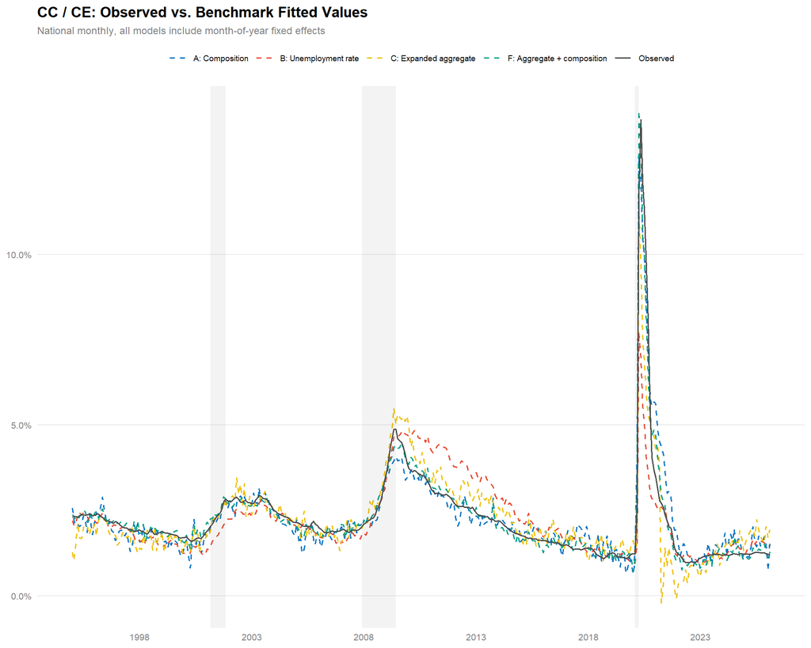

Figure 34: Observed versus fitted CC/CE for selected benchmark models. The composition benchmark (Model A) and the nested model (Model F) are compared against the unemployment-rate-only benchmark (Model B) and the expanded aggregate benchmark (Model C).

```r
fit_colors <- c(
  "Observed" = "grey30",
  "A: Composition" = "#0073C2",
  "B: Unemployment rate" = "#E64B35",
  "C: Expanded aggregate" = "#EFC000",
  "F: Aggregate + composition" = "#00A087"
)

fit_linetypes <- c(
  "Observed" = "solid",
  "A: Composition" = "dashed",
  "B: Unemployment rate" = "dashed",
  "C: Expanded aggregate" = "dashed",
  "F: Aggregate + composition" = "dashed"
)

bench_fitted <- bench_core |>
  transmute(
    date,
    Observed = cc_ce,
    `A: Composition` = fitted(mod_A_cc),
    `B: Unemployment rate` = fitted(mod_B_cc),
    `C: Expanded aggregate` = fitted(mod_C_cc),
    `F: Aggregate + composition` = fitted(mod_F_cc)
  ) |>
  pivot_longer(-date, names_to = "series", values_to = "value")

add_recessions(
  ggplot(bench_fitted, aes(date, value, color = series, linetype = series)) +
    geom_line(linewidth = 0.7) +
    scale_color_manual(values = fit_colors) +
    scale_linetype_manual(values = fit_linetypes) +
    scale_y_continuous(labels = percent_format(accuracy = 0.1)) +
    scale_x_date(date_breaks = "5 years", date_labels = "%Y") +
    labs(
      title = "CC / CE: Observed vs. Benchmark Fitted Values",
      subtitle = "National monthly, all models include month-of-year fixed effects",
      x = NULL, y = NULL
    ) +
    theme(legend.position = "top", legend.text = element_text(size = 7))
)
```

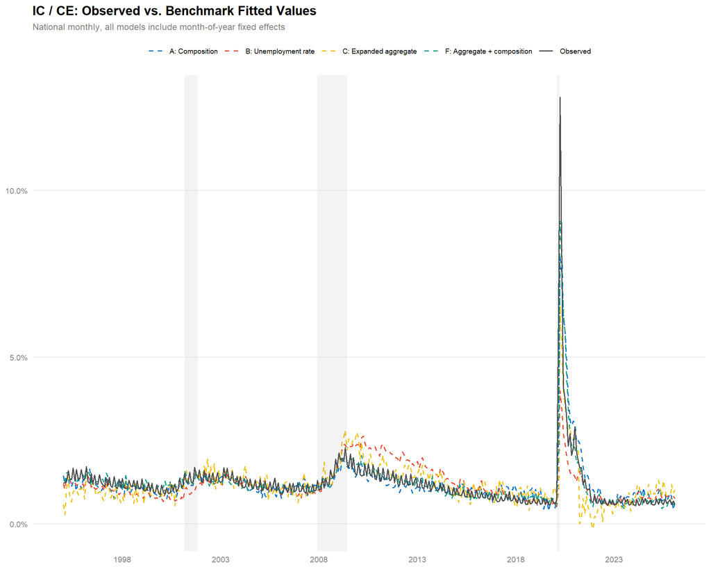

Figure 35: Observed versus fitted IC/CE for selected benchmark models.

```r
bench_fitted_ic <- bench_core |>
  transmute(
    date,
    Observed = ic_ce,
    `A: Composition` = fitted(mod_A_ic),
    `B: Unemployment rate` = fitted(mod_B_ic),
    `C: Expanded aggregate` = fitted(mod_C_ic),
    `F: Aggregate + composition` = fitted(mod_F_ic)
  ) |>
  pivot_longer(-date, names_to = "series", values_to = "value")

add_recessions(
  ggplot(bench_fitted_ic, aes(date, value, color = series, linetype = series)) +
    geom_line(linewidth = 0.7) +
    scale_color_manual(values = fit_colors) +
    scale_linetype_manual(values = fit_linetypes) +
    scale_y_continuous(labels = percent_format(accuracy = 0.1)) +
    scale_x_date(date_breaks = "5 years", date_labels = "%Y") +
    labs(
      title = "IC / CE: Observed vs. Benchmark Fitted Values",
      subtitle = "National monthly, all models include month-of-year fixed effects",
      x = NULL, y = NULL
    ) +
    theme(legend.position = "top", legend.text = element_text(size = 7))
)
```

### Interpretation

The model comparison yields three findings relevant to the paper’s benchmark framing.

**Composition substantially outperforms the unemployment rate alone.** The composition benchmark explains far more variation than the unemployment-rate-only benchmark on both outcomes. The headline unemployment rate captures the broad cyclical pattern of claims intensity but misses substantial variation that the by-cause mix explains.

**Broader macro indicators narrow the gap but do not eliminate it.** The expanded aggregate benchmark and the slack/duration benchmark improve on the unemployment-rate-only specification, as expected for variable sets that jointly proxy the state of the labor market. The JOLTS benchmark contributes additional information about labor-market flows. Yet none of these macro benchmarks consistently dominate the composition model across both outcomes and all fit metrics.

**Composition retains incremental value in the nested specification.** The nested model, which combines the expanded aggregate variables with the composition shares, outperforms both the composition-only and aggregate-only models. This indicates that composition and macro indicators capture partially non-overlapping variation in claims intensity.

## 7.4 Annual By-Cause State-Panel Estimates

The most direct state-panel test of the conceptual framework uses the by-cause shares in an annual state-year panel with state and year fixed effects:

$$y_{st} = \sum_{c \neq \text{CTJ}} \beta_c \, s_{cst} + \alpha_s + \gamma_t + \varepsilon_{st}$$

where $y_{st} \in \{\text{CC/CE}_{st}, \text{IC/CE}_{st}\}$, $s_{cst}$ is the share of unemployment in cause $c$ in state $s$ at time $t$, $\alpha_s$ are state fixed effects, $\gamma_t$ are year fixed effects, and completed temporary jobs are the omitted reference category. Standard errors are clustered by state and regressions are weighted by annual state population. Because the six cause shares sum to one, one category must be excluded; completed temporary jobs are the natural choice because, outside the pandemic period, this group’s share is close to neutral in the correlation diagnostics from Section 4.

The remaining identifying variation is within-state deviation from the national time path after absorbing persistent state differences and common national trends. The design estimates the reduced-form predictive content of by-cause composition for claims intensity; it does not identify the causal effect of any specific compositional shift or barrier to access.

```r
yr_nopan <- panel_year |> filter(!year %in% c(2020L, 2021L))
annual_bycause_rhs <- "temp_layoff_share + perm_job_loser_share + job_leaver_share + reentrant_share + new_entrant_share"
fit_annual_bycause <- function(outcome, data) {
  feols(as.formula(paste0(outcome, " ~ ", annual_bycause_rhs, " | state + year")),
        data = data, weights = ~annual_population, cluster = ~state)
}
ccu_yr_bycause <- fit_annual_bycause("continued_claims_per_covered_employment", panel_year)
icu_yr_bycause <- fit_annual_bycause("initial_claims_per_covered_employment", panel_year)
ccu_yr_bycause_nopan <- fit_annual_bycause("continued_claims_per_covered_employment", yr_nopan)
icu_yr_bycause_nopan <- fit_annual_bycause("initial_claims_per_covered_employment", yr_nopan)
```

**CC/CE**

```r
msummary_styled(
  list("Annual Full" = ccu_yr_bycause, "Annual Excl. Pandemic" = ccu_yr_bycause_nopan),
  title = "Annual By-Cause Composition: Continued Claims / Covered Employment",
  notes = "Annual state-year regressions with state and year fixed effects, state-clustered standard errors, and annual state population weights. Completed temporary jobs are the omitted reference category."
)
```

Annual By-Cause Composition: Continued Claims / Covered Employment

|  | Annual Full | Annual Excl. Pandemic |
| --- | --- | --- |
| temp_layoff_share | 0.059*** | 0.000 |
|  | (0.018) | (0.009) |
| perm_job_loser_share | 0.031*** | 0.026** |
|  | (0.011) | (0.010) |
| job_leaver_share | -0.011 | -0.027*** |
|  | (0.012) | (0.008) |
| reentrant_share | 0.002 | -0.010 |
|  | (0.010) | (0.009) |
| new_entrant_share | 0.011 | 0.001 |
|  | (0.011) | (0.009) |
| Num.Obs. | 1600 | 1500 |
| R2 | 0.894 | 0.915 |
| R2 Adj. | 0.888 | 0.910 |

* p < 0.1, ** p < 0.05, *** p < 0.01  
Annual state-year regressions with state and year fixed effects, state-clustered standard errors, and annual state population weights. Completed temporary jobs are the omitted reference category.

**IC/CE**

```r
msummary_styled(
  list("Annual Full" = icu_yr_bycause, "Annual Excl. Pandemic" = icu_yr_bycause_nopan),
  title = "Annual By-Cause Composition: Initial Claims / Covered Employment",
  notes = "Annual state-year regressions with state and year fixed effects, state-clustered standard errors, and annual state population weights. Completed temporary jobs are the omitted reference category."
)
```

Annual By-Cause Composition: Initial Claims / Covered Employment

|  | Annual Full | Annual Excl. Pandemic |
| --- | --- | --- |
| temp_layoff_share | 0.216 | 0.085 |
|  | (0.132) | (0.091) |
| perm_job_loser_share | 0.106 | 0.068 |
|  | (0.107) | (0.091) |
| job_leaver_share | -0.109 | -0.152** |
|  | (0.089) | (0.067) |
| reentrant_share | -0.060 | -0.094 |
|  | (0.090) | (0.077) |
| new_entrant_share | 0.037 | 0.013 |
|  | (0.094) | (0.073) |
| Num.Obs. | 1600 | 1500 |
| R2 | 0.854 | 0.843 |
| R2 Adj. | 0.846 | 0.834 |

* p < 0.1, ** p < 0.05, *** p < 0.01  
Annual state-year regressions with state and year fixed effects, state-clustered standard errors, and annual state population weights. Completed temporary jobs are the omitted reference category.

The saturated fixed-effects specification shows that much of the raw predictive power of unemployment composition reflects broad aggregate time movement and persistent state differences rather than rich within-state identifying variation. That does not eliminate the usefulness of the composition benchmark. It clarifies that the benchmark’s main value lies in tracking the aggregate evolution of claims intensity rather than in identifying a sharp within-state causal effect.

The reduced-form coefficient patterns are nonetheless informative. In the full-sample CC/CE model, temporary layoffs and permanent job losers load positively relative to the completed-temp-job baseline, indicating that within-state shifts toward those job-loss categories are associated with higher insured-unemployment intensity in the historical data. Excluding the pandemic sharpens the picture and makes the negative job-leaver relationship more apparent. For IC/CE, the coefficients are noisier, which is consistent with initial claims being a flow measure more sensitive to short-run administrative dynamics that the composition benchmark does not capture well.

## 7.5 State-Panel Observed vs. Predicted Gap

For the gap-over-time exercise, the specification drops year fixed effects so that composition must explain the aggregate time path:

$$y_{st} = \sum_{c \neq \text{CTJ}} \beta_c \, s_{cst} + \alpha_s + \varepsilon_{st}
\tag{2}$$

The fitted values are the composition-predicted claims intensity. The population-weighted annual average of $y_{st} - \hat{y}_{st}$ traces the residual gap over time.

```r
fit_annual_gap_model <- function(outcome, data) {
  feols(as.formula(paste0(outcome, " ~ ", annual_bycause_rhs, " | state")),
        data = data, weights = ~annual_population, cluster = ~state)
}
ccu_yr_gap_model <- fit_annual_gap_model("continued_claims_per_covered_employment", panel_year)
icu_yr_gap_model <- fit_annual_gap_model("initial_claims_per_covered_employment", panel_year)

panel_year_gap <- panel_year |>
  mutate(
    cc_ce_hat = predict(ccu_yr_gap_model, newdata = panel_year),
    ic_ce_hat = predict(icu_yr_gap_model, newdata = panel_year)
  )

annual_gap_summary <- panel_year_gap |>
  group_by(year) |>
  summarise(
    date = as.Date(paste0(first(year), "-01-01")),
    observed_cc_ce = weighted.mean(continued_claims_per_covered_employment, annual_population, na.rm = TRUE),
    expected_cc_ce = weighted.mean(cc_ce_hat, annual_population, na.rm = TRUE),
    cc_ce_gap = observed_cc_ce - expected_cc_ce,
    observed_ic_ce = weighted.mean(initial_claims_per_covered_employment, annual_population, na.rm = TRUE),
    expected_ic_ce = weighted.mean(ic_ce_hat, annual_population, na.rm = TRUE),
    ic_ce_gap = observed_ic_ce - expected_ic_ce,
    .groups = "drop"
  )
```

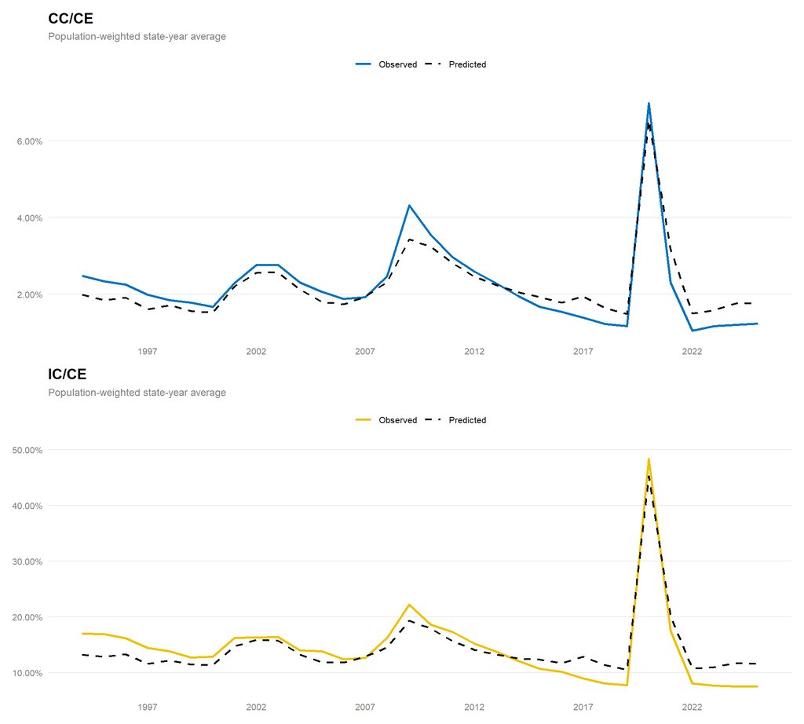

Figure 36: Population-weighted annual observed versus by-cause-predicted claims intensity from a state-year model with state fixed effects only.

```r
(ggplot(annual_gap_summary, aes(date)) +
   geom_line(aes(y = observed_cc_ce, color = "Observed"), linewidth = 0.9) +
   geom_line(aes(y = expected_cc_ce, color = "Predicted"), linewidth = 0.8, linetype = "dashed") +
   scale_color_manual(values = c("Observed" = "#0073C2", "Predicted" = "black")) +
   scale_x_date(date_breaks = "5 years", date_labels = "%Y") +
   scale_y_continuous(labels = percent_format(accuracy = 0.01)) +
   labs(title = "CC/CE", subtitle = "Population-weighted state-year average", x = NULL, y = NULL)) /
  (ggplot(annual_gap_summary, aes(date)) +
     geom_line(aes(y = observed_ic_ce, color = "Observed"), linewidth = 0.9) +
     geom_line(aes(y = expected_ic_ce, color = "Predicted"), linewidth = 0.8, linetype = "dashed") +
     scale_color_manual(values = c("Observed" = "#EFC000", "Predicted" = "black")) +
     scale_x_date(date_breaks = "5 years", date_labels = "%Y") +
     scale_y_continuous(labels = percent_format(accuracy = 0.01)) +
     labs(title = "IC/CE", subtitle = "Population-weighted state-year average", x = NULL, y = NULL)) &
  theme(legend.position = "top")
```

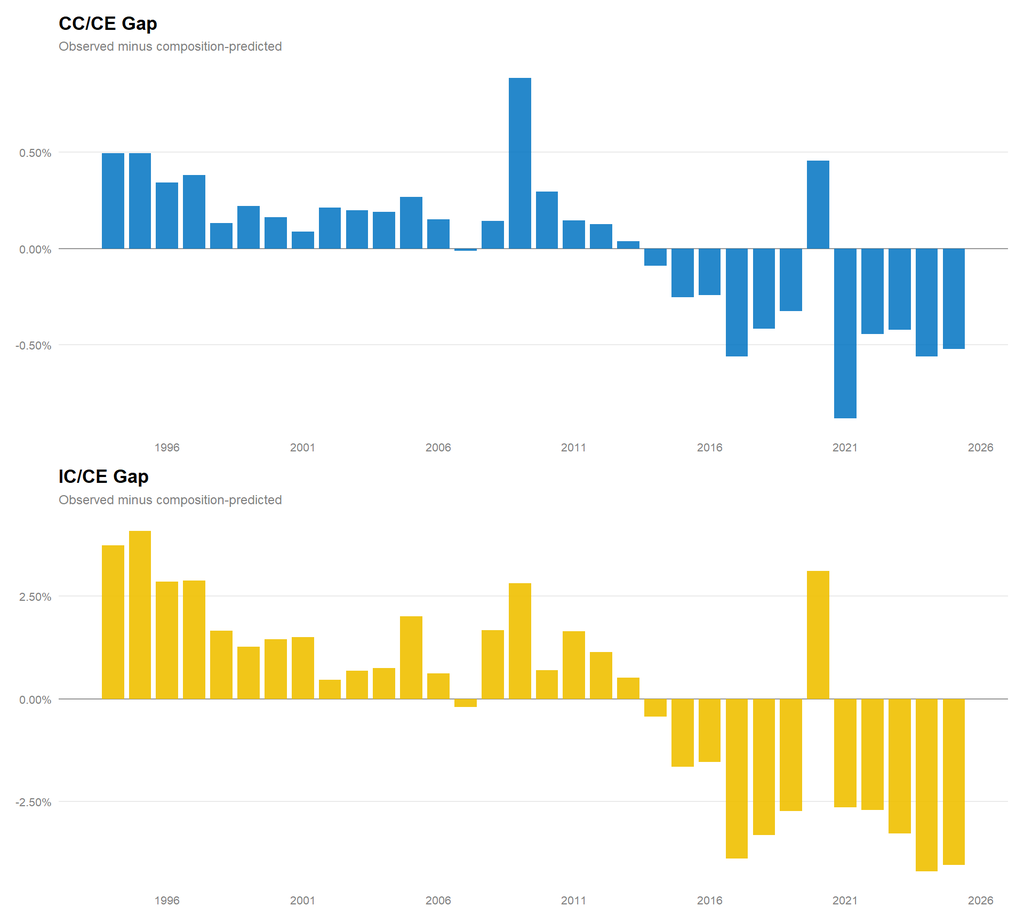

Figure 37: Annual gap between observed and composition-predicted claims intensity. Persistent negative gaps indicate that the composition model overpredicts.

```r
(ggplot(annual_gap_summary, aes(date, cc_ce_gap)) +
   geom_hline(yintercept = 0, color = "grey60", linewidth = 0.5) +
   geom_col(fill = "#0073C2", alpha = 0.85, width = 300) +
   scale_x_date(date_breaks = "5 years", date_labels = "%Y") +
   scale_y_continuous(labels = percent_format(accuracy = 0.01)) +
   labs(title = "CC/CE Gap", subtitle = "Observed minus composition-predicted", x = NULL, y = NULL)) /
  (ggplot(annual_gap_summary, aes(date, ic_ce_gap)) +
     geom_hline(yintercept = 0, color = "grey60", linewidth = 0.5) +
     geom_col(fill = "#EFC000", alpha = 0.9, width = 300) +
     scale_x_date(date_breaks = "5 years", date_labels = "%Y") +
     scale_y_continuous(labels = percent_format(accuracy = 0.01)) +
     labs(title = "IC/CE Gap", subtitle = "Observed minus composition-predicted", x = NULL, y = NULL))
```

With year fixed effects removed, the composition benchmark must account for the time path of claims intensity. The observed and benchmark-predicted lines track each other reasonably well through earlier decades, but a systematic divergence emerges in the modern period: observed claims intensity falls below the benchmark-predicted path and the gap widens materially.

### Comparison: National Aggregate vs. State Panel

The state-panel gap uses state-level composition and absorbs cross-state level differences through state fixed effects. To isolate how much the state FE matter, I collapse the state panel to a single national annual series and compare that gap with the national annual benchmark from Section 7.2.

```r
national_from_panel <- panel_year |>
  group_by(year) |>
  summarise(
    date = as.Date(paste0(first(year), "-01-01")),
    cc_ce = weighted.mean(continued_claims_per_covered_employment, annual_population, na.rm = TRUE),
    ic_ce = weighted.mean(initial_claims_per_covered_employment, annual_population, na.rm = TRUE),
    temp_layoff_share = weighted.mean(temp_layoff_share, annual_population, na.rm = TRUE),
    perm_job_loser_share = weighted.mean(perm_job_loser_share, annual_population, na.rm = TRUE),
    job_leaver_share = weighted.mean(job_leaver_share, annual_population, na.rm = TRUE),
    reentrant_share = weighted.mean(reentrant_share, annual_population, na.rm = TRUE),
    new_entrant_share = weighted.mean(new_entrant_share, annual_population, na.rm = TRUE),
    .groups = "drop"
  )

collapsed_rhs <- "temp_layoff_share + perm_job_loser_share + job_leaver_share + reentrant_share + new_entrant_share"
cc_collapsed <- lm(as.formula(paste0("cc_ce ~ ", collapsed_rhs)), data = national_from_panel)
ic_collapsed <- lm(as.formula(paste0("ic_ce ~ ", collapsed_rhs)), data = national_from_panel)

national_from_panel <- national_from_panel |>
  mutate(
    cc_gap = cc_ce - predict(cc_collapsed),
    ic_gap = ic_ce - predict(ic_collapsed)
  )
```

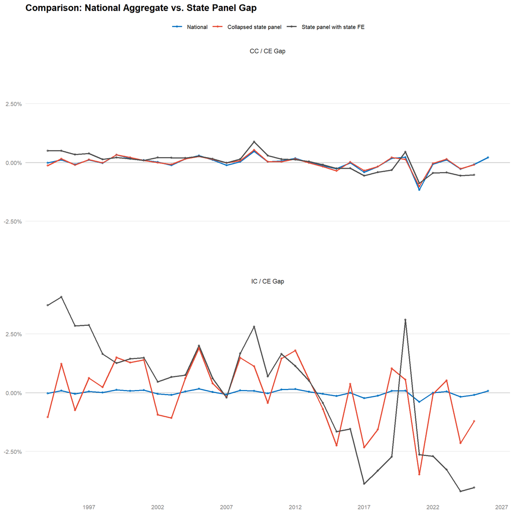

Figure 38: Annual composition gap: national benchmark, collapsed state panel, and state panel with state fixed effects.

```r
gap_comparison <- bind_rows(
  national_annual |>
    transmute(date, cc_gap, ic_gap, source = "National"),
  national_from_panel |>
    transmute(date, cc_gap, ic_gap, source = "Collapsed state panel"),
  annual_gap_summary |>
    transmute(date, cc_gap = cc_ce_gap, ic_gap = ic_ce_gap, source = "State panel with state FE")
) |>
  pivot_longer(c(cc_gap, ic_gap), names_to = "outcome", values_to = "gap") |>
  mutate(
    outcome = recode(outcome, cc_gap = "CC / CE Gap", ic_gap = "IC / CE Gap"),
    source = factor(source, levels = c("National", "Collapsed state panel", "State panel with state FE"))
  )

ggplot(gap_comparison, aes(date, gap, color = source)) +
  geom_hline(yintercept = 0, color = "grey60", linewidth = 0.3) +
  geom_line(linewidth = 0.8) +
  geom_point(size = 1.1, alpha = 0.7) +
  facet_wrap(~outcome, ncol = 1) +
  scale_color_manual(values = c("#0073C2", "#E64B35", "grey30")) +
  scale_y_continuous(labels = percent_format(accuracy = 0.01)) +
  scale_x_date(date_breaks = "5 years", date_labels = "%Y") +
  labs(title = "Comparison: National Aggregate vs. State Panel Gap", x = NULL, y = NULL, color = NULL)
```

## 7.6 National Monthly Two-Group Composition Regressions

As a more aggregated benchmark, I also estimate national monthly regressions that collapse the six reason-for-unemployment categories into two groups: **labor market entrants** (reentrants plus new entrants) and **job separators** (temporary layoffs, permanent job losers, completed temporary jobs, and job leavers). Because the two shares sum to one, the omitted category is **job separators**. The reported coefficient therefore measures how claims intensity changes when unemployment shifts toward labor market entrants and away from job separators, holding month-of-year fixed effects constant.

$$y_t = \alpha + \beta \,\text{EntrantShare}_t + \sum_{m=2}^{12} \gamma_m \mathbf{1}\{\text{month}(t) = m\} + \varepsilon_t$$

where $y_t \in \{CC/CE_t, IC/CE_t\}$ and $\text{EntrantShare}_t$ is the share of unemployment accounted for by labor market entrants in month $t$.

```r
extract_two_group_terms <- function(model, outcome_label) {
  summary(model)$coefficients |>
    as.data.frame() |>
    rownames_to_column("term") |>
    as_tibble() |>
    filter(term == "labor_market_entrant_share") |>
    mutate(
      Outcome = outcome_label,
      Term = "Labor market entrant share",
      `Coef (10 pp shift)` = Estimate * 0.10,
      `Std. Error` = `Std. Error` * 0.10
    ) |>
    select(Outcome, Term, `Coef (10 pp shift)`, `Std. Error`, `p-value` = `Pr(>|t|)`)
}

bind_rows(
  extract_two_group_terms(cc_two_group_model, "CC / CE"),
  extract_two_group_terms(ic_two_group_model, "IC / CE")
) |>
  gt(groupname_col = "Outcome") |>
  fmt_number(columns = c(`Coef (10 pp shift)`, `Std. Error`, `p-value`), decimals = 3) |>
  tab_options(
    table.font.size = px(11),
    column_labels.font.weight = "bold",
    column_labels.background.color = "#2c3e50"
  ) |>
  tab_style(
    style = cell_text(color = "white"),
    locations = cells_column_labels()
  )
```

National monthly regressions of claims intensity on the two-group unemployment composition. Labor market entrants are the included share; job separators are the omitted reference category. Coefficients are scaled to a 10 percentage-point shift in share.

| Term | Coef (10 pp shift) | Std. Error | p-value |
| --- | --- | --- | --- |
| CC / CE |  |  |  |
| Labor market entrant share | −0.023 | 0.001 | 0.000 |
| IC / CE |  |  |  |
| Labor market entrant share | −0.012 | 0.001 | 0.000 |

```r
tibble(
  Outcome = c("CC / CE", "IC / CE"),
  `R-squared` = c(summary(cc_two_group_model)$r.squared, summary(ic_two_group_model)$r.squared),
  RMSE = c(
    sqrt(mean(residuals(cc_two_group_model)^2, na.rm = TRUE)),
    sqrt(mean(residuals(ic_two_group_model)^2, na.rm = TRUE))
  ),
  `Sample Start` = min(takeup_two_group_fitted$date),
  `Sample End` = max(takeup_two_group_fitted$date)
) |>
  mutate(
    `Sample Start` = format(`Sample Start`, "%Y-%m"),
    `Sample End` = format(`Sample End`, "%Y-%m")
  ) |>
  gt() |>
  fmt_number(columns = c(`R-squared`, RMSE), decimals = 3) |>
  tab_options(
    table.font.size = px(11),
    column_labels.font.weight = "bold",
    column_labels.background.color = "#2c3e50"
  ) |>
  tab_style(
    style = cell_text(color = "white"),
    locations = cells_column_labels()
  )
```

Model fit for the national monthly two-group composition regressions.

| Outcome | R-squared | RMSE | Sample Start | Sample End |
| --- | --- | --- | --- | --- |
| CC / CE | 0.673 | 0.008 | 1994-01 | 2026-03 |
| IC / CE | 0.461 | 0.006 | 1994-01 | 2026-03 |

This two-group benchmark asks a narrower question than the six-way model: how much of claims intensity is explained by the balance between labor market entrants and job separators alone? If the coefficient on the entrant share is negative, that means claims intensity is lower in months when unemployment is tilted away from job separators and toward entrants, consistent with weaker UI attachment among the latter group.

## 7.7 National Observed vs. Predicted Claims Intensity: Two-Group Benchmark

The fitted values from the two-group model provide a second national benchmark: the claims intensity predicted by the entrant-versus-separator split plus seasonality, versus what is actually observed.

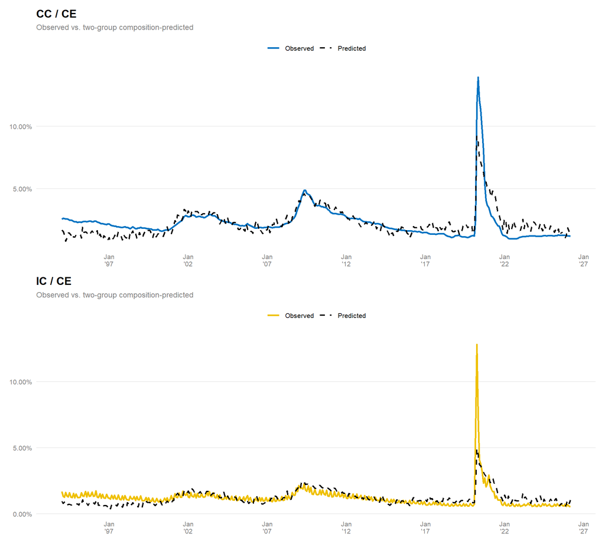

Figure 39: Observed versus composition-predicted national claims intensity from the two-group benchmark, full monthly sample from 1994 onward.

```r
(ggplot(takeup_two_group_fitted, aes(date)) +
   geom_line(aes(y = cc_ce, color = "Observed"), linewidth = 0.9) +
   geom_line(aes(y = cc_ce_hat, color = "Predicted"), linewidth = 0.8, linetype = "dashed") +
   scale_color_manual(values = c("Observed" = "#0073C2", "Predicted" = "black")) +
   scale_x_date(date_breaks = "5 years", date_labels = "%b\n'%y") +
   scale_y_continuous(labels = percent_format(accuracy = 0.01)) +
   labs(title = "CC / CE", subtitle = "Observed vs. two-group composition-predicted", x = NULL, y = NULL)) /
  (ggplot(takeup_two_group_fitted, aes(date)) +
     geom_line(aes(y = ic_ce, color = "Observed"), linewidth = 0.9) +
     geom_line(aes(y = ic_ce_hat, color = "Predicted"), linewidth = 0.8, linetype = "dashed") +
     scale_color_manual(values = c("Observed" = "#EFC000", "Predicted" = "black")) +
     scale_x_date(date_breaks = "5 years", date_labels = "%b\n'%y") +
     scale_y_continuous(labels = percent_format(accuracy = 0.01)) +
     labs(title = "IC / CE", subtitle = "Observed vs. two-group composition-predicted", x = NULL, y = NULL)) &
  theme(legend.position = "top")
```

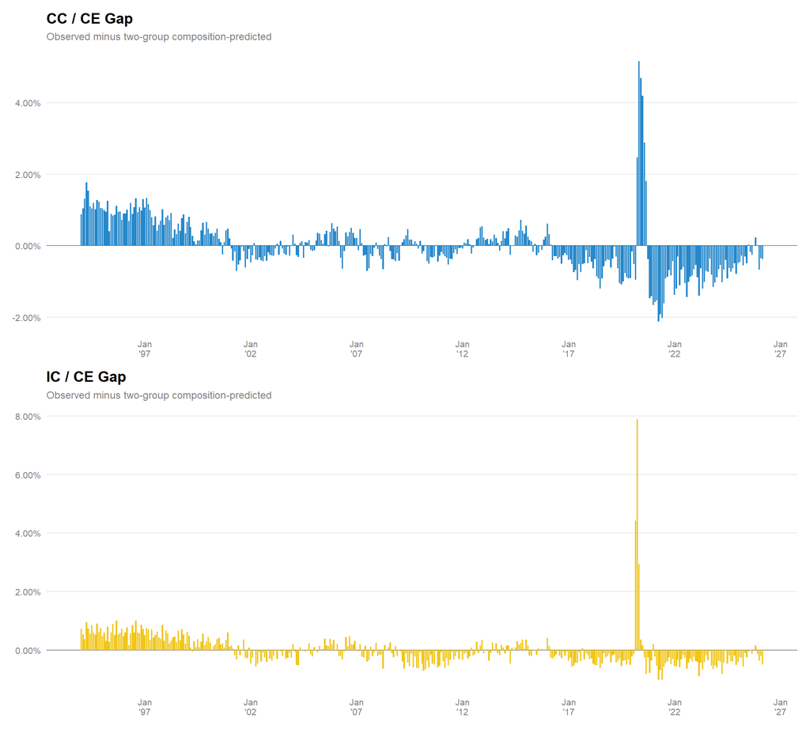

Figure 40: Gap between observed and two-group composition-predicted national claims intensity, full monthly sample from 1994 onward. Negative values mean the two-group model overpredicts.

```r
(ggplot(takeup_two_group_fitted, aes(date, cc_gap)) +
   geom_hline(yintercept = 0, color = "grey60", linewidth = 0.5) +
   geom_col(fill = "#0073C2", alpha = 0.85, width = 25) +
   scale_x_date(date_breaks = "5 years", date_labels = "%b\n'%y") +
   scale_y_continuous(labels = percent_format(accuracy = 0.01)) +
   labs(title = "CC / CE Gap", subtitle = "Observed minus two-group composition-predicted", x = NULL, y = NULL)) /
  (ggplot(takeup_two_group_fitted, aes(date, ic_gap)) +
     geom_hline(yintercept = 0, color = "grey60", linewidth = 0.5) +
     geom_col(fill = "#EFC000", alpha = 0.9, width = 25) +
     scale_x_date(date_breaks = "5 years", date_labels = "%b\n'%y") +
     scale_y_continuous(labels = percent_format(accuracy = 0.01)) +
     labs(title = "IC / CE Gap", subtitle = "Observed minus two-group composition-predicted", x = NULL, y = NULL))
```

The two-group observed-versus-predicted plots show how much explanatory power survives after collapsing the detailed six-way composition into a single entrant-versus-separator margin. Comparing these plots with Sections 7.1 and 7.2 makes it possible to see how much of the six-way benchmark’s fit comes from the broad entrant/separator split versus finer distinctions within job separators and within labor market entrants.

## 7.8 National Monthly Two-Group Regressions by Nativity

I next refine the two-group benchmark by splitting the unemployment pool into four nativity-by-group cells: native entrants, foreign-born entrants, native job separators, and foreign-born job separators. Because these shares sum to one, the omitted category is **native job separators**. The reported coefficients therefore measure how claims intensity changes when unemployment shifts away from native job separators and toward each of the other three groups, holding month-of-year fixed effects constant.

$$y_t = \alpha + \beta_1 \,\text{NativeEntrantShare}_t + \beta_2 \,\text{ForeignBornEntrantShare}_t + \beta_3 \,\text{ForeignBornSeparatorShare}_t + \sum_{m=2}^{12} \gamma_m \mathbf{1}\{\text{month}(t) = m\} + \varepsilon_t$$

where $y_t \in \{CC/CE_t, IC/CE_t\}$ and native job separators are the reference group.

```r
extract_two_group_interaction_terms <- function(model, outcome_label) {
  summary(model)$coefficients |>
    as.data.frame() |>
    rownames_to_column("term") |>
    as_tibble() |>
    filter(term %in% c(
      "native_entrant_share",
      "foreign_born_entrant_share",
      "foreign_born_separator_share"
    )) |>
    mutate(
      Outcome = outcome_label,
      Term = recode(
        term,
        native_entrant_share = "Native entrant share",
        foreign_born_entrant_share = "Foreign-born entrant share",
        foreign_born_separator_share = "Foreign-born separator share"
      ),
      `Coef (10 pp shift)` = Estimate * 0.10,
      `Std. Error` = `Std. Error` * 0.10
    ) |>
    select(Outcome, Term, `Coef (10 pp shift)`, `Std. Error`, `p-value` = `Pr(>|t|)`)
}

bind_rows(
  extract_two_group_interaction_terms(cc_two_group_interaction_model, "CC / CE"),
  extract_two_group_interaction_terms(ic_two_group_interaction_model, "IC / CE")
) |>
  gt(groupname_col = "Outcome") |>
  fmt_number(columns = c(`Coef (10 pp shift)`, `Std. Error`, `p-value`), decimals = 3) |>
  tab_options(
    table.font.size = px(11),
    column_labels.font.weight = "bold",
    column_labels.background.color = "#2c3e50"
  ) |>
  tab_style(
    style = cell_text(color = "white"),
    locations = cells_column_labels()
  )
```

National monthly nativity-by-two-group regressions. Native job separators are the omitted reference category. Coefficients are scaled to a 10 percentage-point shift in share.

| Term | Coef (10 pp shift) | Std. Error | p-value |
| --- | --- | --- | --- |
| CC / CE |  |  |  |
| Native entrant share | −0.019 | 0.002 | 0.000 |
| Foreign-born entrant share | −0.054 | 0.005 | 0.000 |
| Foreign-born separator share | −0.004 | 0.004 | 0.240 |
| IC / CE |  |  |  |
| Native entrant share | −0.012 | 0.002 | 0.000 |
| Foreign-born entrant share | −0.027 | 0.004 | 0.000 |
| Foreign-born separator share | −0.006 | 0.003 | 0.027 |

```r
tibble(
  Outcome = c("CC / CE", "IC / CE"),
  `R-squared` = c(summary(cc_two_group_interaction_model)$r.squared, summary(ic_two_group_interaction_model)$r.squared),
  RMSE = c(
    sqrt(mean(residuals(cc_two_group_interaction_model)^2, na.rm = TRUE)),
    sqrt(mean(residuals(ic_two_group_interaction_model)^2, na.rm = TRUE))
  ),
  `Sample Start` = min(takeup_two_group_interaction_fitted$date),
  `Sample End` = max(takeup_two_group_interaction_fitted$date)
) |>
  mutate(
    `Sample Start` = format(`Sample Start`, "%Y-%m"),
    `Sample End` = format(`Sample End`, "%Y-%m")
  ) |>
  gt() |>
  fmt_number(columns = c(`R-squared`, RMSE), decimals = 3) |>
  tab_options(
    table.font.size = px(11),
    column_labels.font.weight = "bold",
    column_labels.background.color = "#2c3e50"
  ) |>
  tab_style(
    style = cell_text(color = "white"),
    locations = cells_column_labels()
  )
```

Model fit for the national monthly nativity-by-two-group regressions.

| Outcome | R-squared | RMSE | Sample Start | Sample End |
| --- | --- | --- | --- | --- |
| CC / CE | 0.720 | 0.007 | 1994-01 | 2026-03 |
| IC / CE | 0.505 | 0.006 | 1994-01 | 2026-03 |

This specification replaces the interaction model with a directly interpretable four-cell decomposition. Relative to native job separators, the coefficients show whether claims intensity is lower or higher when unemployment is instead concentrated among native entrants, foreign-born entrants, or foreign-born job separators.

## 7.9 National Observed vs. Predicted Claims Intensity: Nativity-by-Two-Group Benchmark

The fitted values from this nativity-by-two-group model provide a third national benchmark: the claims intensity predicted by the four-group decomposition and seasonality, versus what is actually observed.

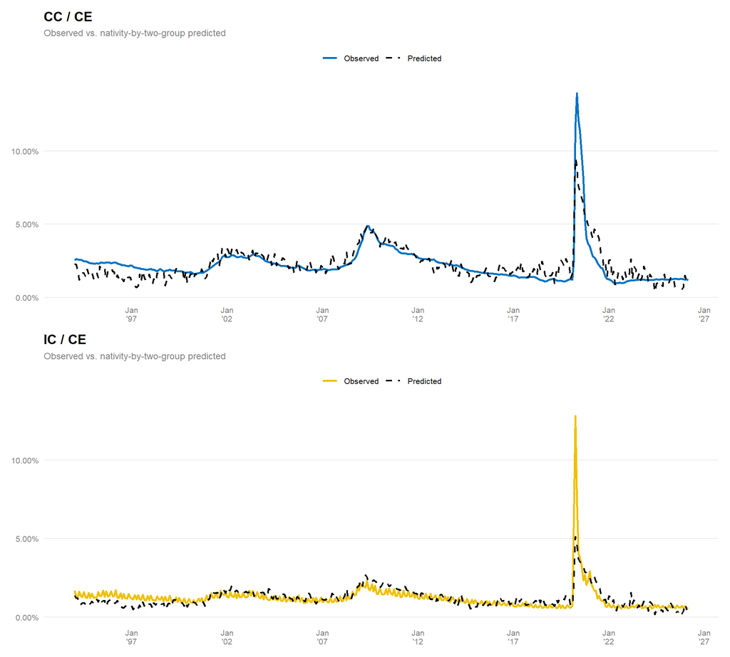

Figure 41: Observed versus composition-predicted national claims intensity from the nativity-by-two-group benchmark, full monthly sample from 1994 onward.

```r
(ggplot(takeup_two_group_interaction_fitted, aes(date)) +
   geom_line(aes(y = cc_ce, color = "Observed"), linewidth = 0.9) +
   geom_line(aes(y = cc_ce_hat, color = "Predicted"), linewidth = 0.8, linetype = "dashed") +
   scale_color_manual(values = c("Observed" = "#0073C2", "Predicted" = "black")) +
   scale_x_date(date_breaks = "5 years", date_labels = "%b\n'%y") +
   scale_y_continuous(labels = percent_format(accuracy = 0.01)) +
   labs(title = "CC / CE", subtitle = "Observed vs. nativity-by-two-group predicted", x = NULL, y = NULL)) /
  (ggplot(takeup_two_group_interaction_fitted, aes(date)) +
     geom_line(aes(y = ic_ce, color = "Observed"), linewidth = 0.9) +
     geom_line(aes(y = ic_ce_hat, color = "Predicted"), linewidth = 0.8, linetype = "dashed") +
     scale_color_manual(values = c("Observed" = "#EFC000", "Predicted" = "black")) +
     scale_x_date(date_breaks = "5 years", date_labels = "%b\n'%y") +
     scale_y_continuous(labels = percent_format(accuracy = 0.01)) +
     labs(title = "IC / CE", subtitle = "Observed vs. nativity-by-two-group predicted", x = NULL, y = NULL)) &
  theme(legend.position = "top")
```

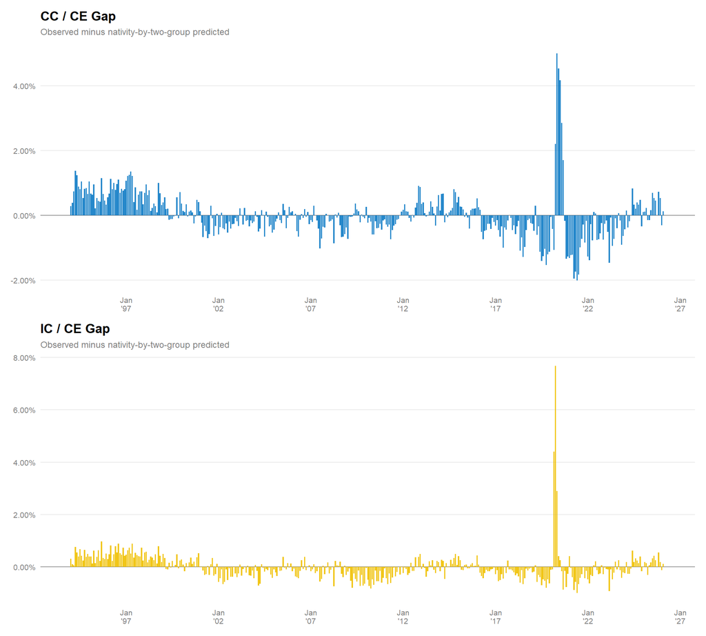

Figure 42: Gap between observed and nativity-by-two-group-predicted national claims intensity, full monthly sample from 1994 onward. Negative values mean the nativity-by-two-group model overpredicts.

```r
(ggplot(takeup_two_group_interaction_fitted, aes(date, cc_gap)) +
   geom_hline(yintercept = 0, color = "grey60", linewidth = 0.5) +
   geom_col(fill = "#0073C2", alpha = 0.85, width = 25) +
   scale_x_date(date_breaks = "5 years", date_labels = "%b\n'%y") +
   scale_y_continuous(labels = percent_format(accuracy = 0.01)) +
   labs(title = "CC / CE Gap", subtitle = "Observed minus nativity-by-two-group predicted", x = NULL, y = NULL)) /
  (ggplot(takeup_two_group_interaction_fitted, aes(date, ic_gap)) +
     geom_hline(yintercept = 0, color = "grey60", linewidth = 0.5) +
     geom_col(fill = "#EFC000", alpha = 0.9, width = 25) +
     scale_x_date(date_breaks = "5 years", date_labels = "%b\n'%y") +
     scale_y_continuous(labels = percent_format(accuracy = 0.01)) +
     labs(title = "IC / CE Gap", subtitle = "Observed minus nativity-by-two-group predicted", x = NULL, y = NULL))
```

These plots show whether separating entrants and job separators by nativity materially improves the national benchmark relative to the simpler two-group model in Sections 7.6 and 7.7. If the fitted paths or residual gaps improve noticeably, that would indicate that nativity composition within the entrant/separator split carries additional information beyond the broad two-group distinction alone.

### Interpretation

The nativity-by-two-group results sharpen the interpretation of the simpler entrant-versus-separator benchmark. Relative to **native job separators**, both **native entrants** and **foreign-born entrants** are associated with significantly lower claims intensity, but the penalty is much larger for **foreign-born entrants**. In the `CC/CE` regression, a 10 percentage-point shift toward native entrants lowers predicted claims intensity by about 2.0 percentage points, while the same shift toward foreign-born entrants lowers it by about 5.4 percentage points. In the `IC/CE` regression, the corresponding magnitudes are about 1.2 and 2.7 percentage points. By contrast, **foreign-born job separators** look much closer to **native job separators**, especially in the `CC/CE` specification, where the difference is small and not statistically distinguishable from zero.

This pattern suggests that the nativity margin matters mainly within the **entrant** category, not uniformly across the entire unemployed pool. The broad two-group result remains intact: entrants are less closely linked to UI claims than job separators. But the decomposition shows that this relationship is especially strong when the unemployment increase comes from **foreign-born entrants**, whereas **foreign-born separators** are much more similar to the omitted benchmark of native job separators. In that sense, nativity appears to add explanatory power not through a general foreign-born penalty, but through the particularly weak claims-intensity association of the **foreign-born entrant** margin.

# 8. Interpretation

The results support a two-part conclusion.

**The composition benchmark has substantial reduced-form predictive content.** At the national level, by-cause unemployment shares and seasonality account for roughly 90 percent of the variation in CC/CE and 74 percent in IC/CE. Relative to completed temporary jobs, higher shares of job leavers and new entrants are associated with significantly lower claims intensity, consistent with these groups’ weaker UI attachment. In the state panel with both state and year fixed effects, the within $R^2$ drops sharply, indicating that much of the raw predictive power of unemployment composition reflects persistent state differences and common national time movement rather than rich within-state identifying variation. This does not invalidate the composition benchmark; it clarifies that the benchmark’s value lies in tracking the aggregate evolution of claims intensity rather than in identifying sharp within-state effects. When year fixed effects are dropped and composition must account for the time path, the within $R^2$ rises substantially, confirming that composition tracks the broad level and cyclical pattern of claims intensity under the historical reduced-form relationship.

The residual is consistent with several non-composition factors the literature has identified:

- Administrative burden: burdens in UI have increased and may depress claiming.
- Employer deterrence: firm effects on claiming are substantial, with high-appeal firms showing lower claim rates.
- Benefit generosity: declining real generosity would reduce claiming conditional on unemployment composition.
- State policy tightening: several states shortened durations and tightened administration after the Great Recession.
- Racial and demographic disparities: persistent gaps in UI receipt can operate through claiming conditional on eligibility rather than eligibility itself.
- Information frictions and stigma: perceived ineligibility and other barriers can suppress application behavior among otherwise relevant workers.

This paper does not identify which of these channels dominates. The reduced-form design lacks the individual-level variation in eligibility, employer behavior, or administrative friction needed for that identification. What it does establish is the quantitative benchmark: how much of the variation in claims intensity is accounted for by the observable composition of unemployment under the historical reduced-form relationship, and therefore how large the residual is that mechanism-specific studies must collectively explain.

# 9. Conclusion

The composition of unemployment accounts for a meaningful share of the variation in UI claims intensity under the historical reduced-form relationship but does not fully account for the modern shortfall. The by-cause composition of unemployment, particularly the shares of job leavers and new entrants relative to the near-neutral completed-temp-job category, tracks the broad level and cyclical pattern of claims intensity at the national level and in state-panel models where within-state and within-year fixed effects absorb the aggregate confounds that a single national time series cannot isolate. The remaining gap is substantial, has turned persistently negative since roughly 2014, and has widened through 2024 to 2025.

This paper provides a composition-based benchmark for UI claims intensity and shows that recent claims intensity falls below the level historically associated with the realized unemployment mix. The literature has long recognized that job losers are more UI-relevant than new entrants, but it has not systematically estimated how much reduced-form explanatory leverage that compositional fact provides in a panel setting. The answer is: substantial, but not sufficient. The unexplained residual is large and growing, indicating that a complete account of low UI claims intensity requires understanding both the composition of the unemployment pool and the non-composition factors that shape claiming behavior.

The value of the composition benchmark rests on its institutional content, not on fit alone. Reason-for-unemployment categories are not data-mined predictors; they map directly onto the eligibility architecture of the UI system, giving the benchmark a clear interpretation that generic macro covariates would lack. Other variable sets that comove with the same cyclical and secular forces could also track the national time path reasonably well, but they would not answer the question the benchmark is designed to address: how much of the observed path of claims intensity is consistent with shifts in who becomes unemployed and how close those individuals are to the UI system’s historically intended beneficiaries? The composition benchmark is useful not because it is the only variable set that could fit the data, but because it is the one whose fit has direct institutional content.

Three implications follow. First, the by-cause unemployment mix offers a conceptually principled and empirically useful benchmark for UI claims intensity, one grounded in the structure of the program itself. Second, the residual gap between observed and composition-predicted claims intensity quantifies the target that institutional, administrative, and behavioral explanations must collectively account for. Third, the composition channel is likely to become more important as the structure of the labor market continues to evolve, with shifts in occupational mix, gig employment, and immigration patterns all affecting who shows up in the unemployment count and how close those individuals are to the UI system’s originally intended beneficiaries.

# Explainer for Safi

This note clarifies why the state-panel estimated residual can sit below the national residual so consistently, even when the code is working as intended.

Let the national residual be

$$r^{N}_t = y^{N}_t - \hat y^{N}_t$$

where $y^{N}_t$ is national claims intensity and $\hat y^{N}_t$ comes from the national aggregate regression.

Let the state-panel residual be

$$r^{S}_t = \sum_s \omega_{st}\bigl(y_{st} - \hat y_{st}\bigr)$$

where $\omega_{st}$ are population weights and

$$\hat y_{st} = \alpha_s + x'_{st}\beta$$

comes from the state fixed-effects model.

Then the difference between the two residual series is

$$r^{S}_t - r^{N}_t
=
\Bigl[\sum_s \omega_{st} y_{st} - y^{N}_t\Bigr]
-
\Bigl[\sum_s \omega_{st}\hat y_{st} - \hat y^{N}_t\Bigr].$$

So there are only two sources of divergence:

1. Outcome aggregation difference:

$$\sum_s \omega_{st} y_{st} - y^{N}_t$$

The population-weighted state outcome is not exactly the same object as the national series.

2. Prediction-model difference:

$$\sum_s \omega_{st}\hat y_{st} - \hat y^{N}_t$$

This is usually the bigger piece. The state-panel model predicts using state intercepts and state-level composition, while the national model predicts from one aggregate regression.

If the weighted state fixed-effects prediction is systematically higher than the national prediction, then

$$\sum_s \omega_{st}\hat y_{st} > \hat y^{N}_t$$

which implies

$$r^{S}_t < r^{N}_t.$$

That is the algebraic version of the intuition: the state-panel benchmark is often a tougher counterfactual, so it leaves a more negative residual.